# Trees

Justin Post

September 20, 2016

This presentation will represent a replication of some analysis done in the article [Control factors and scale analysis of annual river water, sediments and carbon transport in China](http://www.nature.com/articles/srep25963).

The data available to download there or on SLG website. A description of variables available [here](http://www.nature.com/articles/srep25963/tables/1).

Let’s get started!

```r
#install packages if needed
#install.packages(c("rpart","dplyr","ggplot2","corrplot","rpart.plot"))
#load packages
library(rpart)
library(rpart.plot)
library(dplyr)
library(ggplot2)
library(corrplot)

#read in data
River<-tbl_df(read.csv("F:/SLG/Trees/data.csv",header=TRUE))
River
```

```
## Source: local data frame [316 x 38]
##
##    ID References           Author  Climate             Name
## 1   1          1 Chen et al. 2005 Semiarid    Daheihe River
## 2   2          1 Chen et al. 2005 Semiarid    Dawenhe River
## 3   3          1 Chen et al. 2005 Semiarid      Fenhe River
## 4   4          1 Chen et al. 2005 Semiarid  Huangshui River
## 5   5          1 Chen et al. 2005 Semiarid   Kushuihe River
## 6   6          1 Chen et al. 2005 Semiarid     Kuyehe River
## 7   7          1 Chen et al. 2005 Semiarid      Luohe River
## 8   8          1 Chen et al. 2005 Semiarid Qingshuihe River
## 9   9          1 Chen et al. 2005 Semiarid      Qinhe River
## 10 10          1 Chen et al. 2005 Semiarid      Taohe River
## .. ..        ...              ...      ...              ...
## Variables not shown: Outlet.Name (fctr), Yrs (int), Size.km2. (dbl), L.km.
##   (dbl), RD.mm. (dbl), QA (dbl), Rc (dbl), TSSC.mg.L. (dbl),
##   TSSL.g.m.2.a.1. (dbl), POCC (dbl), DOCC (dbl), PICC (dbl), DICC (dbl),
##   TOCC..mg.L. (dbl), POCL (dbl), DOCL (dbl), PICL (dbl), DICL (dbl),
##   TOCL..g.m.2.a.1. (dbl), Total.Rainfall (dbl), MAP (dbl), MAT (dbl), S
##   (dbl), LAT (dbl), LONG (dbl), LU (fctr), Vc... (dbl), RSCI... (dbl),
##   SOC... (dbl), BD.g.cm3. (dbl), CLAY... (int), SILT... (int), X (lgl)
```

## Table 2 from paper

We’ll start by recreating part of table 2. We first need to create a new variable corresponding to the size.

```r
#attach data
attach(River)
#create new classification variable
River<-tbl_df(data.frame(River,Size.Class=ifelse(Size.km2.<15000,"Small",
                                          ifelse(Size.km2.<100000,"Medium",
                                          ifelse(Size.km2.<350000,"Sizeable",
                                          ifelse(Size.km2.<700000,"Large","Great"))))))
detach(River)
attach(River)
```

There are a few ways to find the mean of a variable for each category of the others:

```r
#Find means of Rc, TSSC, TSSL, TOCL by each level of the Size variable
#Note - this only uses complete case analysis!
aggregate(cbind(Rc,TSSC.mg.L.,TSSL.g.m.2.a.1.,TOCL..g.m.2.a.1.)~Size.Class,FUN=mean,na.rm=TRUE,data=River)
```

```
##   Size.Class        Rc TSSC.mg.L. TSSL.g.m.2.a.1. TOCL..g.m.2.a.1.
## 1      Great 0.1819450  3681.3118       166.98140         1.436088
## 2      Large 0.2820593  1055.2540       136.37933         2.704329
## 3     Medium 0.4295809   139.4198        60.74411         2.463519
## 4   Sizeable 0.1960466   407.7334        73.66786         2.030912
## 5      Small 0.3590320   154.1447       158.90509         2.854646
```

```r
#For each variable instead (slightly different here and there...)
#Rc
aggregate(Rc~Size.Class,FUN=mean,na.rm=TRUE,data=River)
```

```
##   Size.Class        Rc
## 1      Great 0.3211937
## 2      Large 0.3605108
## 3     Medium 0.4095992
## 4   Sizeable 0.3390982
## 5      Small 0.3495683
```

```r
aggregate(Rc~Size.Class,FUN=length,data=River)
```

```
##   Size.Class Rc
## 1      Great 62
## 2      Large 63
## 3     Medium 73
## 4   Sizeable 54
## 5      Small 62
```

```r
  #combined
  data.frame(aggregate(Rc~Size.Class,FUN=mean,na.rm=TRUE,data=River),
           Count=aggregate(Rc~Size.Class,FUN=length,data=River)[,2])
```

```
##   Size.Class        Rc Count
## 1      Great 0.3211937    62
## 2      Large 0.3605108    63
## 3     Medium 0.4095992    73
## 4   Sizeable 0.3390982    54
## 5      Small 0.3495683    62
```

```r
#TSSC
data.frame(aggregate(TSSC.mg.L.~Size.Class,FUN=mean,na.rm=TRUE,data=River),
           Count=aggregate(TSSC.mg.L.~Size.Class,FUN=length,data=River)[,2])
```

```
##   Size.Class TSSC.mg.L. Count
## 1      Great  3430.4107    55
## 2      Large  1522.7320    59
## 3     Medium  3169.2662    59
## 4   Sizeable   818.6973    52
## 5      Small  3239.1998    33
```

```r
#TSSL
data.frame(aggregate(TSSL.g.m.2.a.1.~Size.Class,FUN=mean,na.rm=TRUE,data=River),
           Count=aggregate(TSSL.g.m.2.a.1.~Size.Class,FUN=length,data=River)[,2])
```

```
##   Size.Class TSSL.g.m.2.a.1. Count
## 1      Great        254.6282    56
## 2      Large        237.3619    55
## 3     Medium        362.1980    65
## 4   Sizeable        274.2079    53
## 5      Small        655.8795    57
```

```r
#TOCL
data.frame(aggregate(TOCL..g.m.2.a.1.~Size.Class,FUN=mean,na.rm=TRUE,data=River),
           Count=aggregate(TOCL..g.m.2.a.1.~Size.Class,FUN=length,data=River)[,2])
```

```
##   Size.Class TOCL..g.m.2.a.1. Count
## 1      Great         1.298840    16
## 2      Large         3.602708    18
## 3     Medium         2.771944    13
## 4   Sizeable         1.937476     8
## 5      Small         1.927187    29
```

Using the dplry package this can be done easily as well. Here we’ll use chaining - which is a little easier to parse.

```r
#alternatively use dplyr
River %>% group_by(Size.Class) %>% summarise(mean(Rc,na.rm=TRUE))
```

```
## Source: local data frame [5 x 2]
##
##   Size.Class mean(Rc, na.rm = TRUE)
## 1      Great              0.3211937
## 2      Large              0.3605108
## 3     Medium              0.4095992
## 4   Sizeable              0.3390982
## 5      Small              0.3495683
```

```r
River %>% group_by(Size.Class) %>% summarise(count=sum(!is.na(Rc)))
```

```
## Source: local data frame [5 x 2]
##
##   Size.Class count
## 1      Great    62
## 2      Large    63
## 3     Medium    73
## 4   Sizeable    54
## 5      Small    62
```

```r
  #combined
  data.frame(River %>% group_by(Size.Class) %>% summarise(mean(Rc,na.rm=TRUE)),
      select(River %>% group_by(Size.Class) %>% summarise(count=sum(!is.na(Rc))),count))
```

```
##   Size.Class mean.Rc..na.rm...TRUE. count
## 1      Great              0.3211937    62
## 2      Large              0.3605108    63
## 3     Medium              0.4095992    73
## 4   Sizeable              0.3390982    54
## 5      Small              0.3495683    62
```

## Figure 2 recreation

First we’ll find the correlation matrix and save it to use in the corrplot function from the corrplot package.

```r
#find correlation matrix using spearman's rank
Correlation<-cor(select(River,RD.mm.,MAP,Rc,MAT,DOCL,TOCL..g.m.2.a.1.,SOC...,QA,Vc...,S,POCL,
                      TSSL.g.m.2.a.1.,Size.km2.,LONG,TSSC.mg.L.,DOCC,BD.g.cm3.,POCC,RSCI...,LAT),
                      use="pairwise.complete.obs",method="spearman")
Correlation[1:5,1:5]
```

```
##           RD.mm.       MAP        Rc       MAT      DOCL
## RD.mm. 1.0000000 0.9247327 0.9203540 0.7461050 0.7403132
## MAP    0.9247327 1.0000000 0.7482512 0.8565119 0.6549514
## Rc     0.9203540 0.7482512 1.0000000 0.5245391 0.6952855
## MAT    0.7461050 0.8565119 0.5245391 1.0000000 0.3448927
## DOCL   0.7403132 0.6549514 0.6952855 0.3448927 1.0000000
```

Now the corrplot function makes a really beautiful plot of this info.

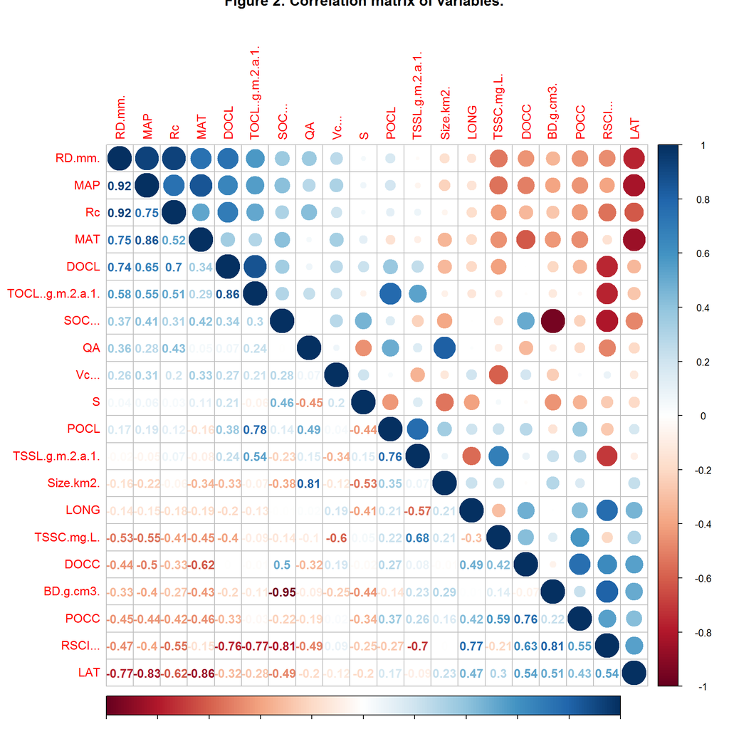

```r
corrplot(Correlation,type="upper",title="Figure 2: Correlation matrix of variables.",tl.pos="lt")
corrplot(Correlation,type="lower",method="number",add=TRUE,diag=FALSE,tl.pos="n")
```

## Figure 3a recreation

There are many packages to create trees in R, we’ll use the rpart package as that is what the authors did.

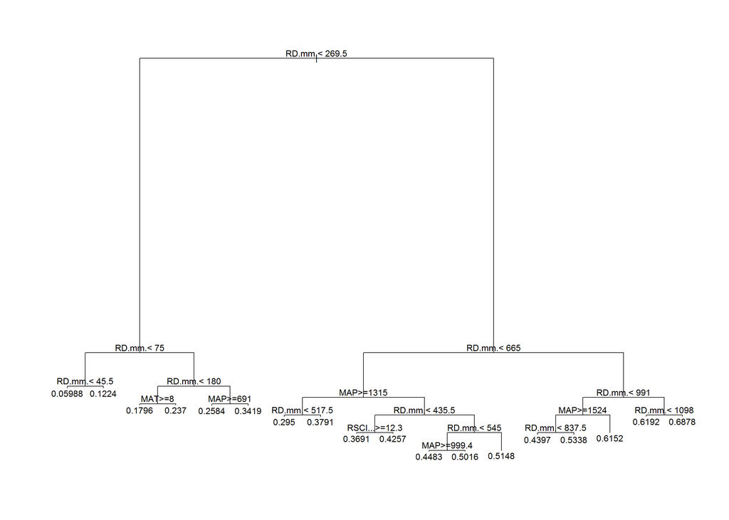

```r
#create tree for Rc
rpart_tree<-rpart(formula=Rc~MAP+MAT+RSCI...+RD.mm.+S+Vc...,data=River,method="anova",cp=0.001)
#plot it
plot(rpart_tree)
text(rpart_tree)
```

A greedy forward seeking algorithm is done until some stopping criteria is met. The function tries to minimize the residual sum of squares for each split using the mean of the response as the predictor in each split. More on this later.

Looking at the plot I didn’t really like it, found the companion package rpart.plot.

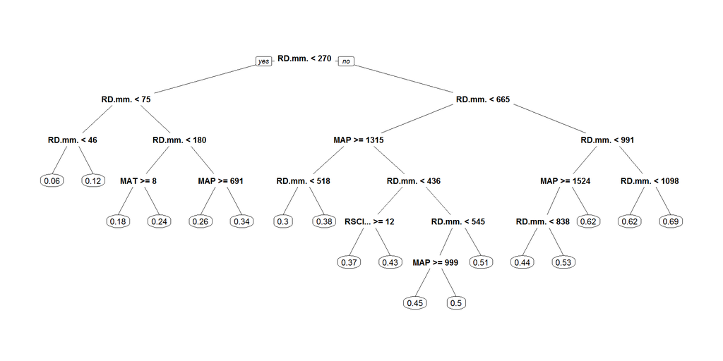

```r
#better plot
rpart.plot(rpart_tree)
```

The tree that is fit is pretty large, we probably want to prune it back a bit. There are a number of ways to decide on how to prune, we’ll look at the cp (or cost-complexity pruning) statistic to choose the pruning level.

```r
#look at stats
printcp(rpart_tree)
```

```
##
## Regression tree:
## rpart(formula = Rc ~ MAP + MAT + RSCI... + RD.mm. + S + Vc...,
##     data = River, method = "anova", cp = 0.001)
##
## Variables actually used in tree construction:
## [1] MAP     MAT     RD.mm.  RSCI...
##
## Root node error: 10.92/314 = 0.034777
##
## n=314 (2 observations deleted due to missingness)
##
##           CP nsplit rel error   xerror      xstd
## 1  0.6934882      0  1.000000 1.003922 0.0596460
## 2  0.1051210      1  0.306512 0.319740 0.0243871
## 3  0.0785374      2  0.201391 0.223105 0.0173285
## 4  0.0179604      3  0.122853 0.142336 0.0151874
## 5  0.0168454      4  0.104893 0.130150 0.0134466
## 6  0.0111198      5  0.088048 0.105308 0.0096269
## 7  0.0088982      6  0.076928 0.101386 0.0089080
## 8  0.0080642      7  0.068029 0.098733 0.0088139
## 9  0.0044477      8  0.059965 0.088667 0.0081761
## 10 0.0039286      9  0.055518 0.074682 0.0071817
## 11 0.0038954     10  0.051589 0.072519 0.0071118
## 12 0.0034761     11  0.047694 0.069419 0.0064754
## 13 0.0029990     12  0.044217 0.068728 0.0064191
## 14 0.0029069     13  0.041219 0.068493 0.0064267
## 15 0.0026636     14  0.038312 0.067624 0.0065466
## 16 0.0019818     15  0.035648 0.064890 0.0065070
## 17 0.0017125     16  0.033666 0.059877 0.0060950
## 18 0.0010000     17  0.031954 0.058027 0.0054661
```

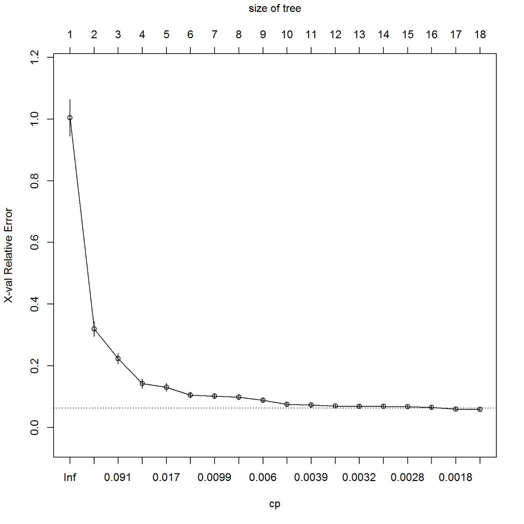

```r
plotcp(rpart_tree)
```

There is a rule of thumb called the one-standard error rule. Pick the most parsimonious (smallest) possible that is within one standard error of the lowest Cross-Validation Mean Squared Error. Let’s just trim it down to the 6th smallest tree.

```r
#prune it and replot
prune(rpart_tree,cp=0.009)
```

```
## n=314 (2 observations deleted due to missingness)
##
## node), split, n, deviance, yval
##       * denotes terminal node
##
##  1) root 314 10.92007000 0.35831680
##    2) RD.mm.< 269.5 126  1.16289600 0.16861950
##      4) RD.mm.< 75 58  0.07677690 0.07928774 *
##      5) RD.mm.>=75 68  0.22848570 0.24481430 *
##    3) RD.mm.>=269.5 188  2.18423200 0.48545430
##      6) RD.mm.< 665 125  0.55331700 0.42997980
##       12) MAP>=1315 30  0.09652996 0.35949150 *
##       13) MAP< 1315 95  0.26065810 0.45223920 *
##      7) RD.mm.>=665 63  0.48298710 0.59552280
##       14) RD.mm.< 991 35  0.21105340 0.54719160
##         28) MAP>=1524.5 20  0.06742503 0.49618130 *
##         29) MAP< 1524.5 15  0.02219914 0.61520540 *
##       15) RD.mm.>=991 28  0.08798110 0.65593690 *
```

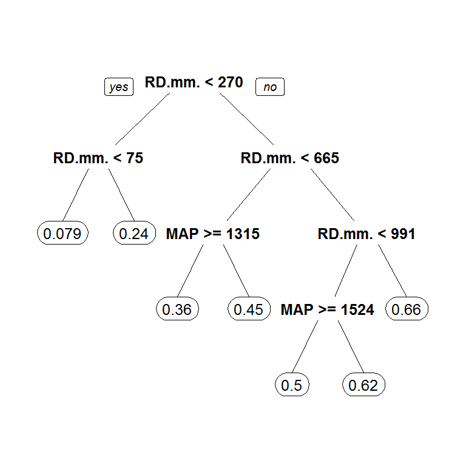

```r
rpart.plot(prune(rpart_tree,cp=0.009))
```

Different than their tree, let’s try to recreate that…

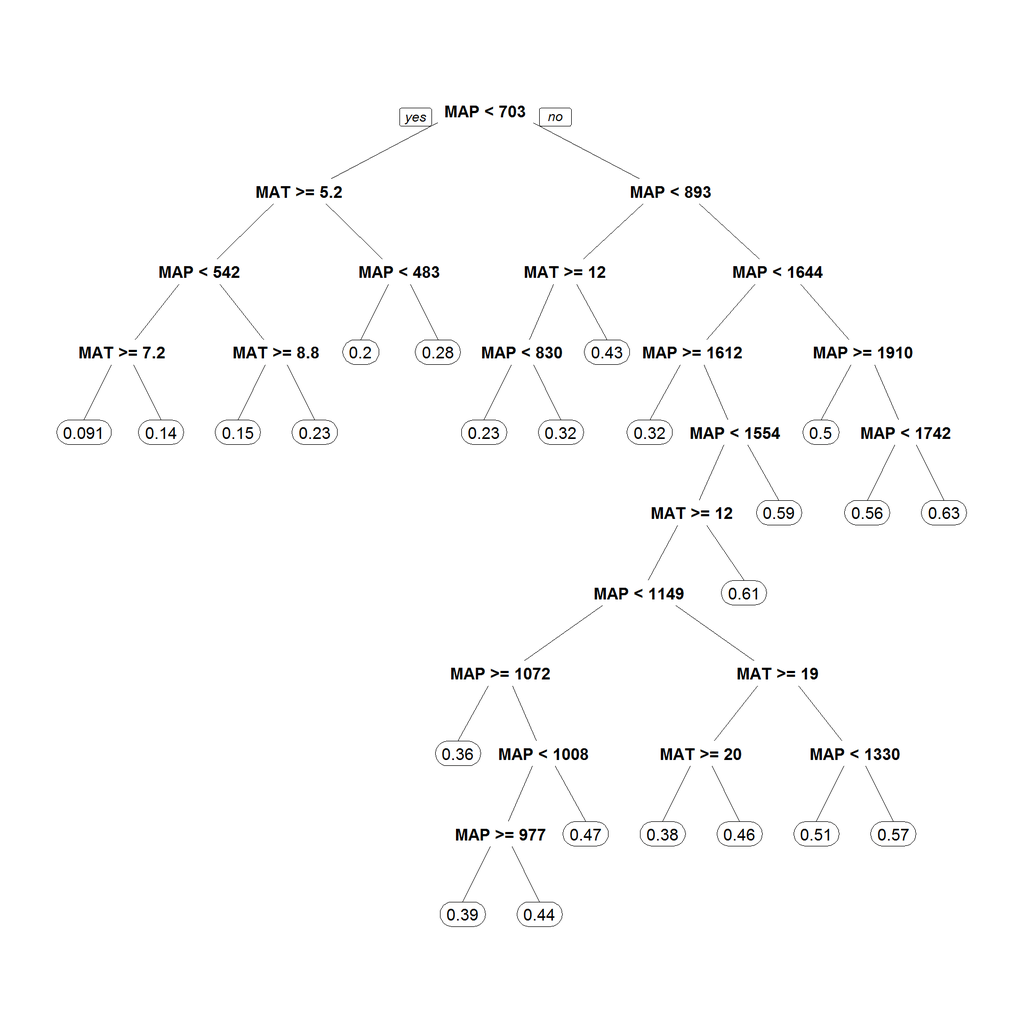

```r
#recreate with only the variables they ended with
rpart_tree<-rpart(formula=Rc~MAP+MAT,data=River,method="anova",cp=0.001)
#plot it
rpart.plot(rpart_tree)
```

```r
#look at stats
printcp(rpart_tree)
```

```
##
## Regression tree:
## rpart(formula = Rc ~ MAP + MAT, data = River, method = "anova",
##     cp = 0.001)
##
## Variables actually used in tree construction:
## [1] MAP MAT
##
## Root node error: 10.92/314 = 0.034777
##
## n=314 (2 observations deleted due to missingness)
##
##           CP nsplit rel error  xerror     xstd
## 1  0.5616296      0   1.00000 1.00866 0.060231
## 2  0.0499358      1   0.43837 0.45078 0.037487
## 3  0.0323751      2   0.38843 0.43717 0.041204
## 4  0.0266279      3   0.35606 0.41652 0.040196
## 5  0.0237150      4   0.32943 0.38419 0.040598
## 6  0.0194100      5   0.30572 0.35305 0.040033
## 7  0.0142667      6   0.28631 0.35056 0.038278
## 8  0.0104188      8   0.25777 0.33098 0.037339
## 9  0.0093409      9   0.24735 0.33005 0.037543
## 10 0.0068778     11   0.22867 0.31839 0.036693
## 11 0.0042904     12   0.22179 0.30294 0.035767
## 12 0.0036812     13   0.21750 0.29854 0.033528
## 13 0.0036731     14   0.21382 0.29940 0.033607
## 14 0.0036254     15   0.21015 0.29940 0.033607
## 15 0.0035283     16   0.20652 0.29706 0.032532
## 16 0.0025975     17   0.20300 0.29534 0.032394
## 17 0.0021232     18   0.20040 0.29403 0.032219
## 18 0.0021050     19   0.19828 0.29337 0.032056
## 19 0.0016566     20   0.19617 0.29302 0.032065
## 20 0.0010000     22   0.19286 0.29338 0.031827
```

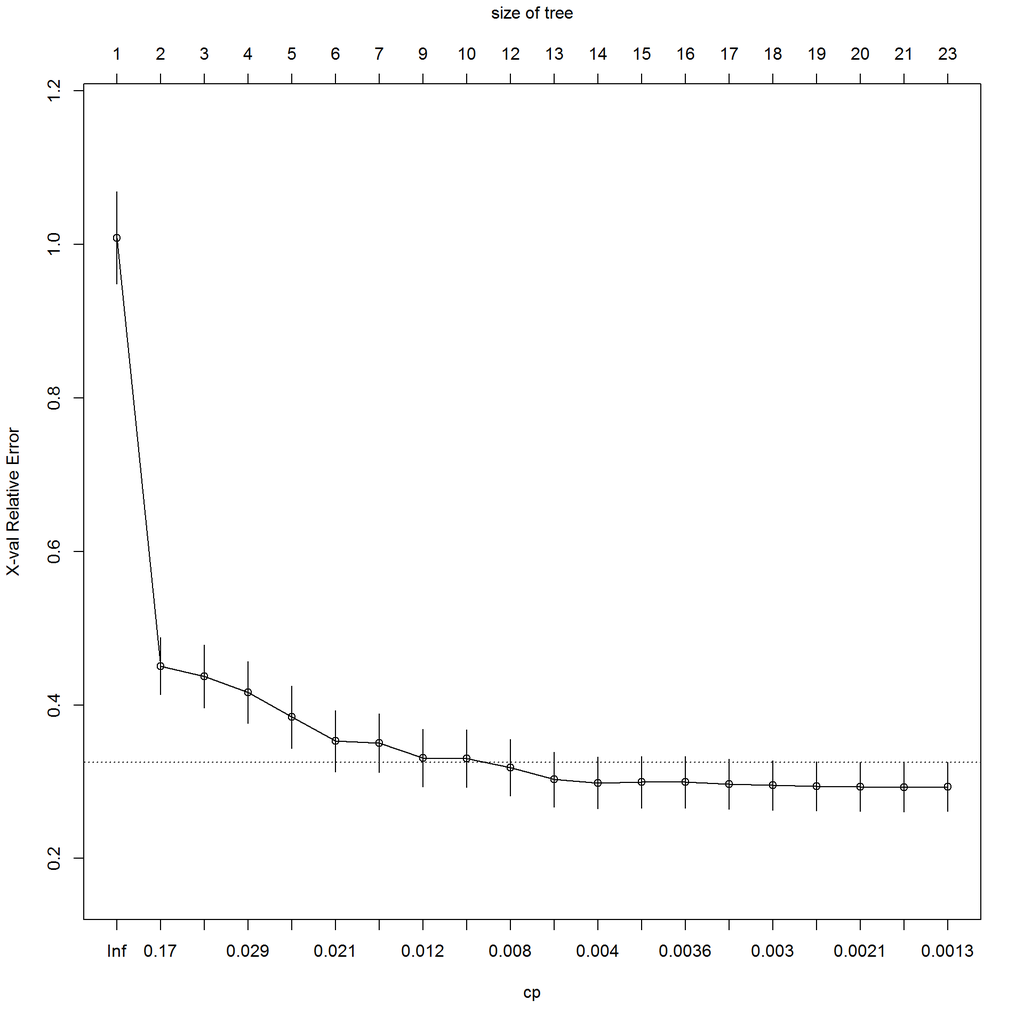

```r
plotcp(rpart_tree)
```

```r
#prune it and replot
prune(rpart_tree,cp=0.02)
```

```
## n=314 (2 observations deleted due to missingness)
##
## node), split, n, deviance, yval
##       * denotes terminal node
##
##  1) root 314 10.92007000 0.3583168
##    2) MAP< 703 103  1.06071700 0.1582867
##      4) MAT>=5.25 77  0.60750760 0.1274119 *
##      5) MAT< 5.25 26  0.16243060 0.2497235 *
##    3) MAP>=703 211  3.72631700 0.4559618
##      6) MAP< 893 38  0.44108210 0.3474921
##       12) MAT>=12 20  0.15634900 0.2691756 *
##       13) MAT< 12 18  0.02576396 0.4345105 *
##      7) MAP>=893 173  2.73993300 0.4797875
##       14) MAP< 1644.1 137  1.83393800 0.4566143 *
##       15) MAP>=1644.1 36  0.55245680 0.5679745 *
```

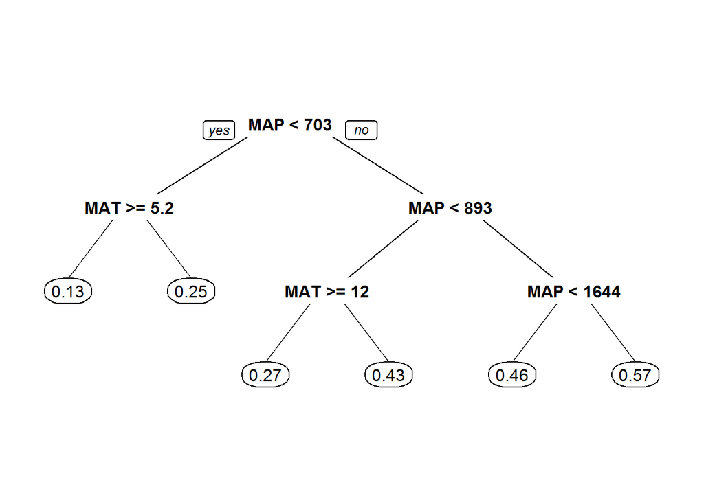

```r
rpart.plot(prune(rpart_tree,cp=0.02))
```

## Figure 4a recreation

To recreate this we’ll use ggplot2. Note that levels of a factor have an underlying ordering.

```r
#overwrite Size.Class to have proper ordering
River$Size.Class<-ordered(Size.Class,levels=c("Small","Medium","Sizeable","Large","Great"))
#to add coloring for points - need MAP variable first
River<-tbl_df(data.frame(River,MAT.Class= ifelse(MAP<600,"Semiarid",
                                          ifelse(MAP>=600 & MAP<850,"Moist",
                                          ifelse(MAP>=850 & MAP<1500,"Humid","Wet")))))
#reorder valeus
River$MAT.Class<-ordered(River$MAT.Class,levels=c("Semiarid","Moist","Humid","Wet"))
```

Now we can step through the creation of the plot. [ggplot2 cheat sheet](https://www.rstudio.com/wp-content/uploads/2015/03/ggplot2-cheatsheet.pdf)

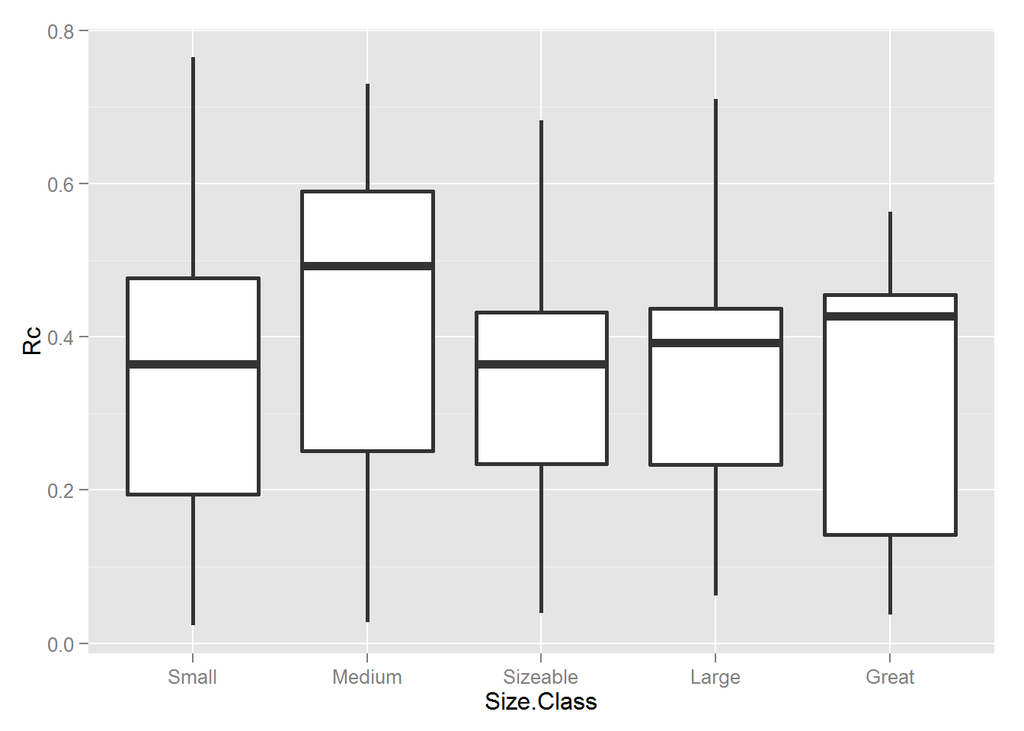

```r
#create plot - base plotting object
g<-ggplot(data=River,aes(x=Size.Class,y=Rc))
#add layer for boxplots
g+geom_boxplot(lwd=1)
```

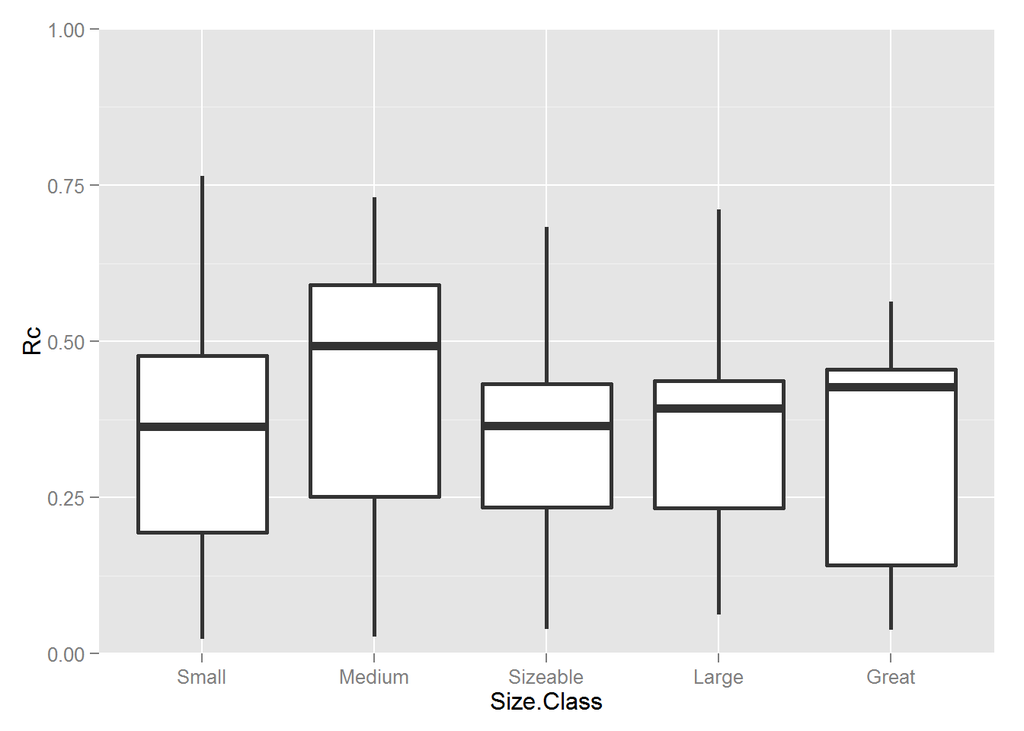

```r
#fix y scale
g+geom_boxplot(lwd=1)+coord_cartesian(ylim=c(0,1))
```

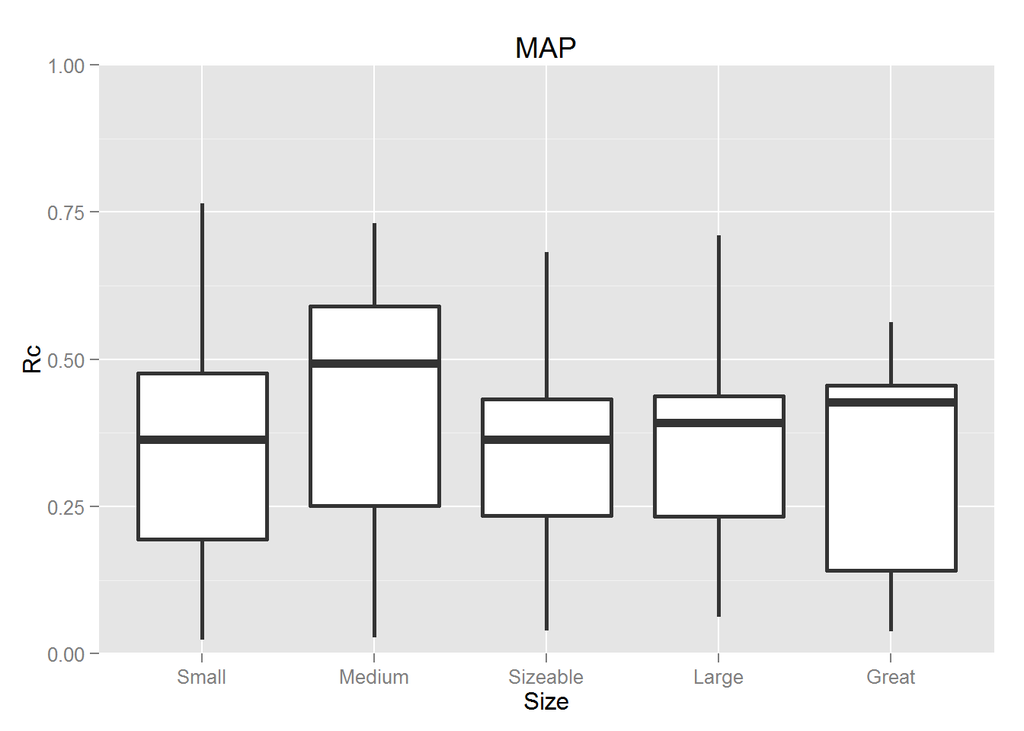

```r
#fix labeling
g+geom_boxplot(lwd=1)+coord_cartesian(ylim=c(0,1))+labs(title="MAP",x="Size")
```

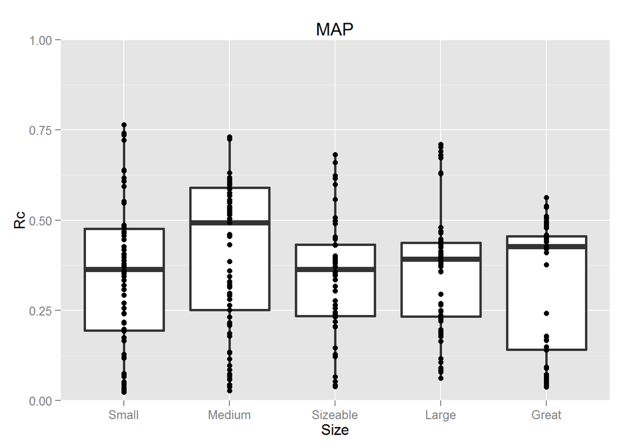

```r
#add layer for points
g+geom_boxplot(lwd=1)+coord_cartesian(ylim=c(0,1))+labs(title="MAP",x="Size")+
  geom_point()
```

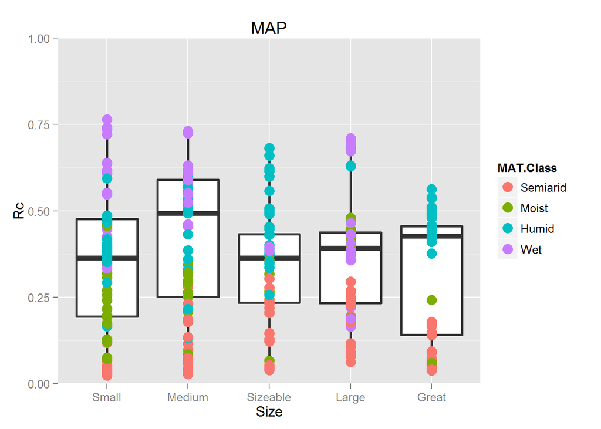

```r
#add coloring
g+geom_boxplot(lwd=1)+coord_cartesian(ylim=c(0,1))+labs(title="MAP",x="Size")+
  geom_point(aes(col=MAT.Class),size=4)
```

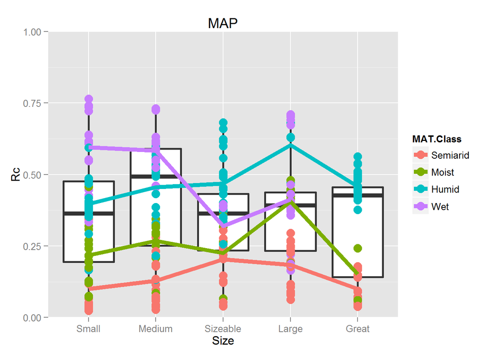

```r
#add connecting lines for each group
g+geom_boxplot(lwd=1)+coord_cartesian(ylim=c(0,1))+labs(title="MAP",x="Size")+
  geom_point(aes(col=MAT.Class),size=4)+
  stat_summary(fun.y=mean,geom="line",lwd=2,aes(group=MAT.Class,col=MAT.Class))
```

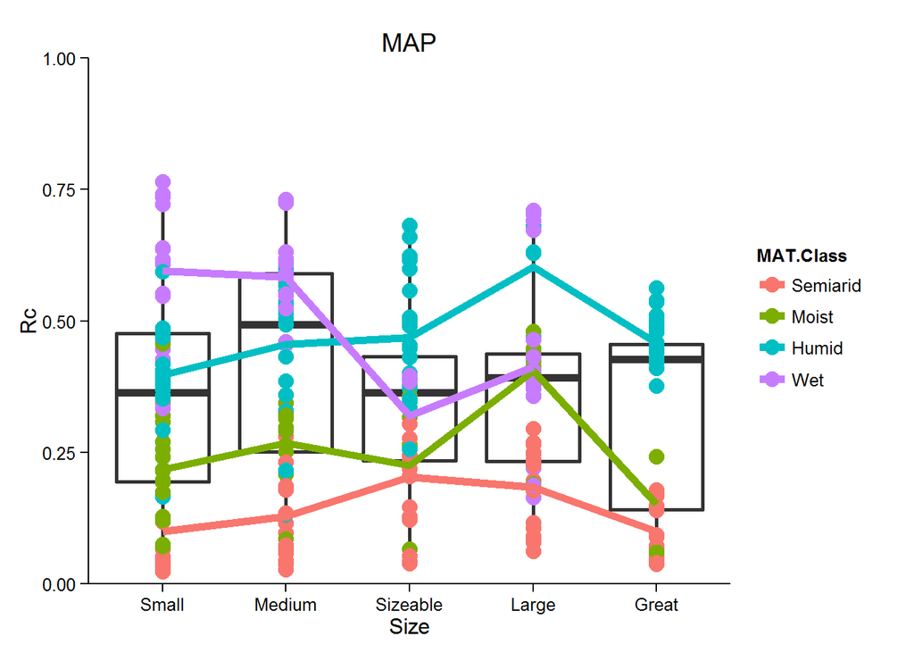

```r
#change background theme
g+geom_boxplot(lwd=1)+coord_cartesian(ylim=c(0,1))+labs(title="MAP",x="Size")+
  geom_point(aes(col=MAT.Class),size=4)+
  stat_summary(fun.y=mean,geom="line",lwd=2,aes(group=MAT.Class,col=MAT.Class))+
  theme_classic()
```

## More about trees!

Let’s compare Simple Linear Regression with a Regression Tree.

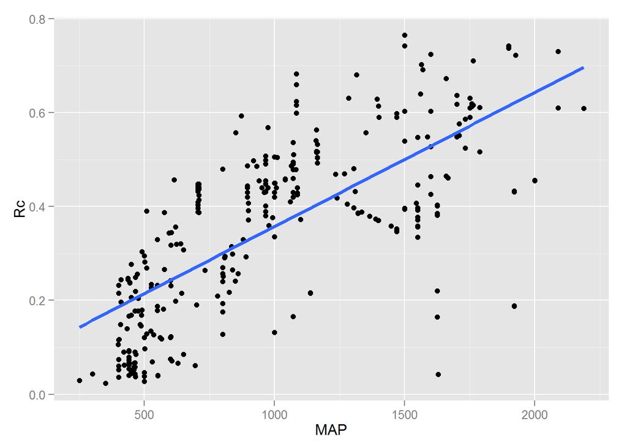

```r
g<-ggplot(data=River,aes(x=MAP,y=Rc))
#plot SLR between MAP and Rc
g+geom_point()+geom_smooth(method="lm",se=FALSE,lwd=1.25)
```

The line provides a prediction for a given value of MAP.

```r
#fit tree with just MAP to predict Rc
rpart_tree<-rpart(formula=Rc~MAP,data=River,method="anova",cp=0.001)
#look at stats
printcp(rpart_tree)
```

```
##
## Regression tree:
## rpart(formula = Rc ~ MAP, data = River, method = "anova", cp = 0.001)
##
## Variables actually used in tree construction:
## [1] MAP
##
## Root node error: 10.92/314 = 0.034777
##
## n=314 (2 observations deleted due to missingness)
##
##           CP nsplit rel error  xerror     xstd
## 1  0.5616296      0   1.00000 1.01091 0.060055
## 2  0.0499358      1   0.43837 0.45063 0.037580
## 3  0.0323751      2   0.38843 0.43807 0.038636
## 4  0.0194100      3   0.35606 0.39438 0.037056
## 5  0.0159065      4   0.33665 0.39331 0.037698
## 6  0.0148038      5   0.32074 0.38809 0.037209
## 7  0.0136822      6   0.30594 0.37707 0.037406
## 8  0.0085165      7   0.29226 0.36089 0.035114
## 9  0.0068778      9   0.27522 0.35302 0.034391
## 10 0.0055854     10   0.26835 0.35165 0.034715
## 11 0.0047170     12   0.25718 0.35537 0.035555
## 12 0.0025975     13   0.25246 0.35794 0.035650
## 13 0.0024519     14   0.24986 0.35375 0.033935
## 14 0.0022647     16   0.24496 0.35536 0.034059
## 15 0.0020842     18   0.24043 0.35606 0.034187
## 16 0.0018653     19   0.23834 0.35371 0.034214
## 17 0.0014397     23   0.23016 0.35220 0.033558
## 18 0.0010000     25   0.22728 0.35500 0.033774
```

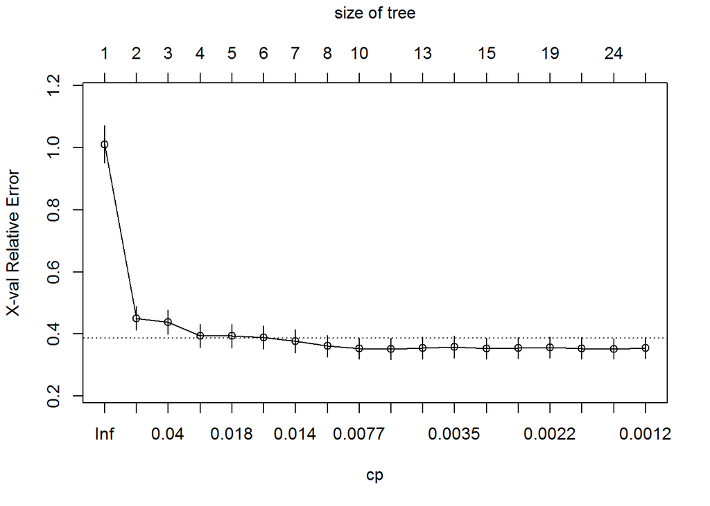

```r
plotcp(rpart_tree)
```

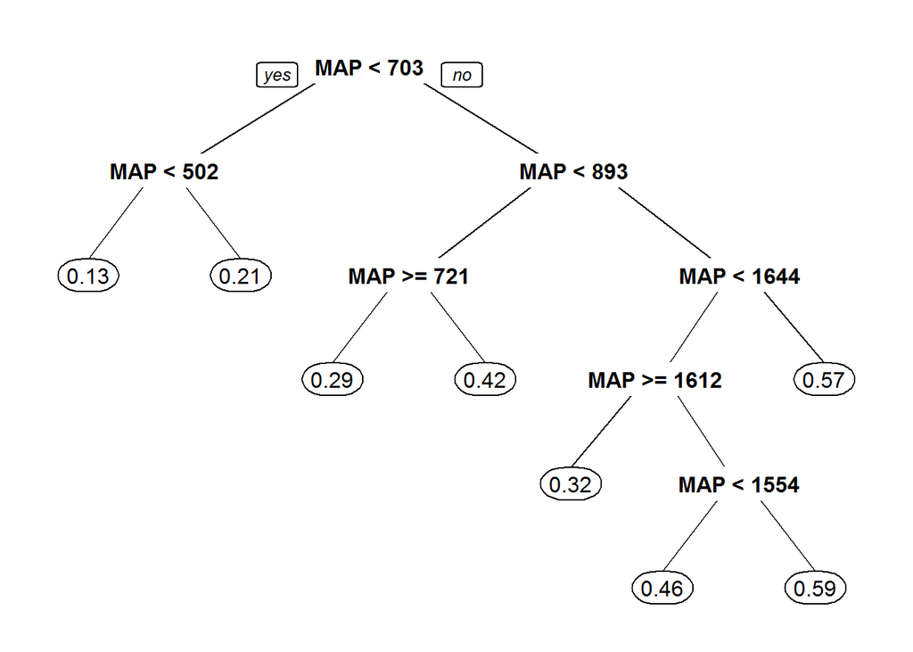

```r
#prune it and replot
rpart.plot(prune(rpart_tree,cp=0.01))
```

Now let’s put both predictions on the same graph to compare.

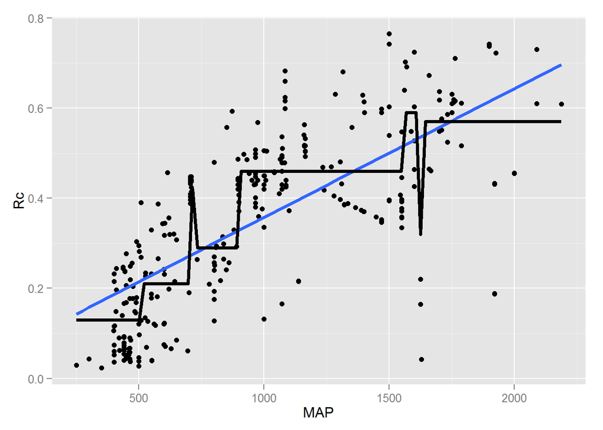

```r
fun<-function(MAP){ifelse(MAP<502,0.13,
                  ifelse(MAP<703,0.21,
                  ifelse(MAP<721,0.42,
                  ifelse(MAP<893,0.29,
                  ifelse(MAP<1554,0.46,
                  ifelse(MAP<1612,0.59,
                  ifelse(MAP<1644,0.32,0.57)))))))
}

#add regression tree prediction
g+geom_point()+geom_smooth(method="lm",se=FALSE,lwd=1.25)+
  stat_function(fun=fun,lwd=1.25)
```

### Same but with two predictors

We’ll need some packages for plotting in 3d.

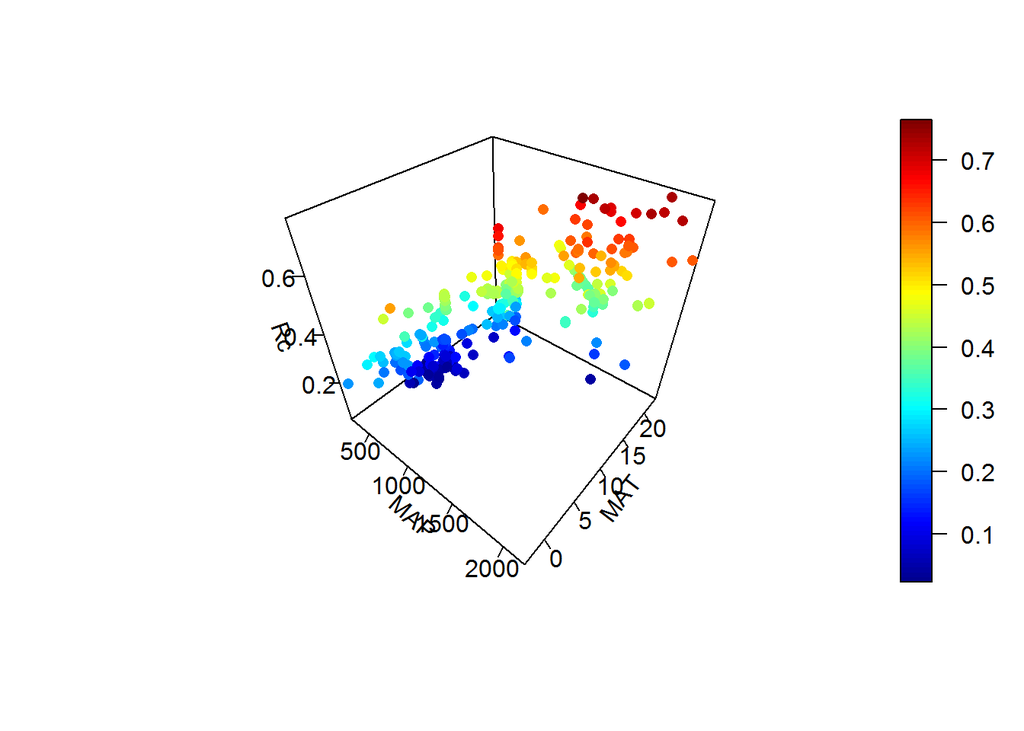

```r
#install.packages("plot3D","plot3Drgl")
library(plot3D)
library(plot3Drgl)

scatter3D(x=MAP,y=MAT,z=Rc,pch=16,ticktype="detailed",
          xlab="MAP",ylab="MAT",zlab="Rc")
```

[interactive chart not shown]

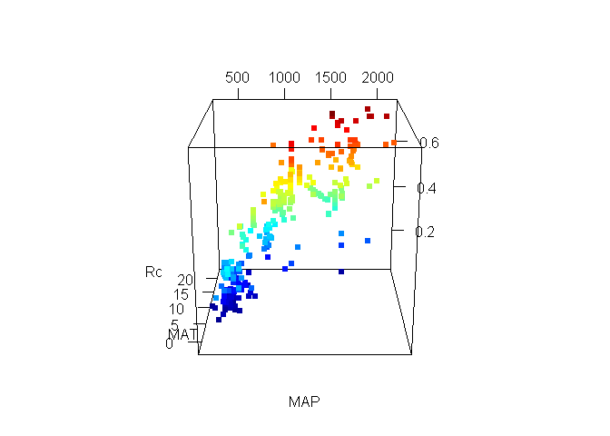

```r
plotrgl()
```

Let’s add in regression surface. First we can get the fit.

```r
#MLR fit
fit<-lm(Rc~MAP+MAT,data=River)
summary(fit)
```

```
##
## Call:
## lm(formula = Rc ~ MAP + MAT, data = River)
##
## Residuals:
##      Min       1Q   Median       3Q      Max
## -0.49054 -0.09802  0.00827  0.09854  0.35506
##
## Coefficients:
##               Estimate Std. Error t value Pr(>|t|)
## (Intercept)  9.897e-02  1.830e-02   5.408 1.27e-07 ***
## MAP          3.684e-04  2.722e-05  13.534  < 2e-16 ***
## MAT         -8.284e-03  2.268e-03  -3.653 0.000304 ***
## ---
## Signif. codes:  0 '***' 0.001 '**' 0.01 '*' 0.05 '.' 0.1 ' ' 1
##
## Residual standard error: 0.1264 on 311 degrees of freedom
##   (2 observations deleted due to missingness)
## Multiple R-squared:  0.5447, Adjusted R-squared:  0.5418
## F-statistic: 186.1 on 2 and 311 DF,  p-value: < 2.2e-16
```

Now we can create a grid of values to plot this surface over.

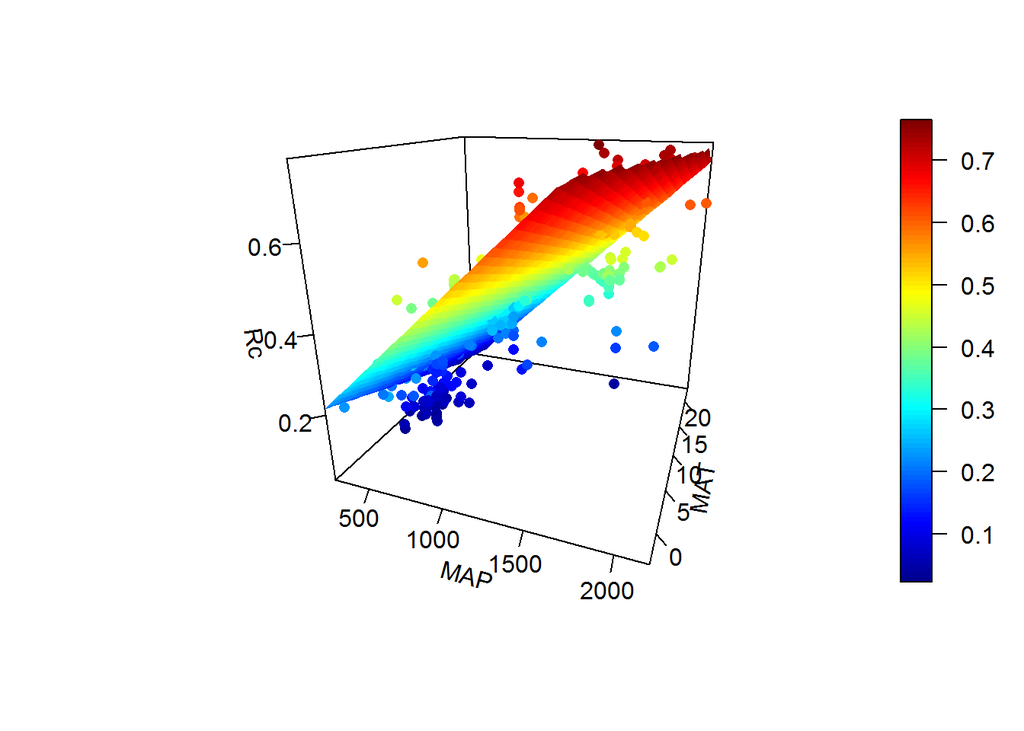

```r
grid.lines = 40
x.pred <- seq(min(MAP), max(MAP), length.out = grid.lines)
y.pred <- seq(min(MAT), max(MAT), length.out = grid.lines)
xy <- expand.grid( MAP = x.pred, MAT = y.pred)
z.pred <- matrix(predict(fit, newdata = xy),
                 nrow = grid.lines, ncol = grid.lines)
# scatter plot with regression plane
scatter3D(x=MAP, y=MAT, z=Rc, pch = 16, cex = 1,
          theta = 20, phi = 20, ticktype = "detailed",
          xlab = "MAP", ylab = "MAT", zlab = "Rc",
          surf = list(x = x.pred, y = y.pred, z = z.pred))
```

[interactive chart not shown]

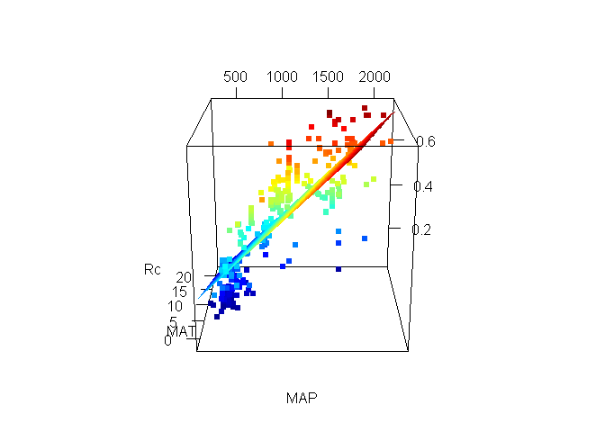

```r
plotrgl()
```

Samething but with interaction.

```r
#add in regression surface with interaction
fit<-lm(Rc~MAP+MAT+MAP*MAT,data=River)
summary(fit)
```

```
##
## Call:
## lm(formula = Rc ~ MAP + MAT + MAP * MAT, data = River)
##
## Residuals:
##      Min       1Q   Median       3Q      Max
## -0.44642 -0.06632  0.00459  0.07358  0.36753
##
## Coefficients:
##               Estimate Std. Error t value Pr(>|t|)
## (Intercept) -2.771e-01  4.286e-02  -6.465 3.93e-10 ***
## MAP          9.770e-04  6.860e-05  14.243  < 2e-16 ***
## MAT          1.337e-02  3.037e-03   4.400 1.49e-05 ***
## MAP:MAT     -3.353e-05  3.540e-06  -9.472  < 2e-16 ***
## ---
## Signif. codes:  0 '***' 0.001 '**' 0.01 '*' 0.05 '.' 0.1 ' ' 1
##
## Residual standard error: 0.1115 on 310 degrees of freedom
##   (2 observations deleted due to missingness)
## Multiple R-squared:  0.6469, Adjusted R-squared:  0.6435
## F-statistic: 189.3 on 3 and 310 DF,  p-value: < 2.2e-16
```

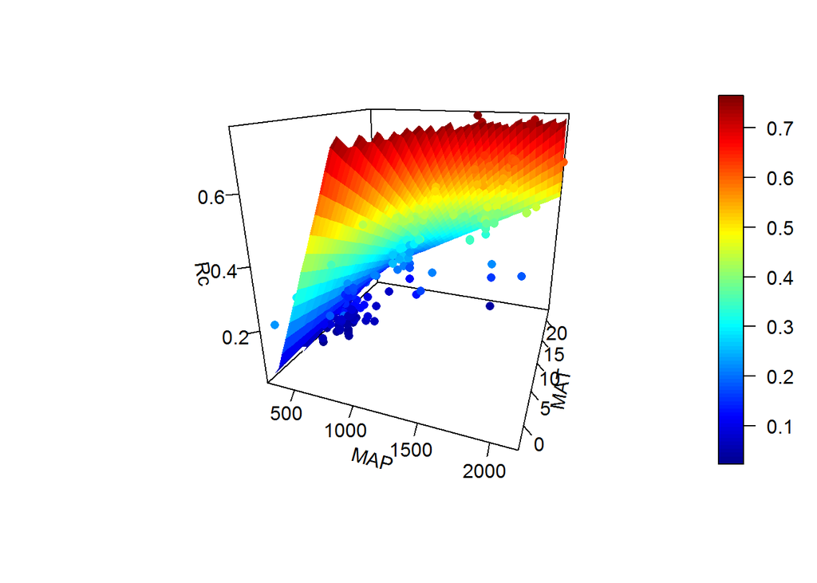

```r
grid.lines = 40
x.pred <- seq(min(MAP), max(MAP), length.out = grid.lines)
y.pred <- seq(min(MAT), max(MAT), length.out = grid.lines)
xy <- expand.grid( MAP = x.pred, MAT = y.pred)
z.pred <- matrix(predict(fit, newdata = xy),
                 nrow = grid.lines, ncol = grid.lines)
# scatter plot with regression plane
scatter3D(x=MAP, y=MAT, z=Rc, pch = 16, cex = 1,
          theta = 20, phi = 20, ticktype = "detailed",
          xlab = "MAP", ylab = "MAT", zlab = "Rc",
          surf = list(x = x.pred, y = y.pred, z = z.pred))
```

[interactive chart not shown]

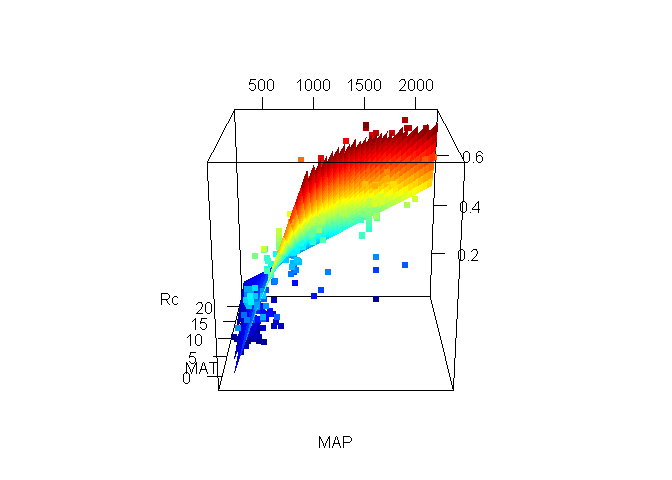

```r
plotrgl()
```

Now let’s get the tree prediction for those two variables and plot that.

```r
#Obtain tree prediction
rpart_tree<-rpart(formula=Rc~MAP+MAT,data=River,method="anova",cp=0.001)
#look at stats and plot
printcp(rpart_tree)
```

```
##
## Regression tree:
## rpart(formula = Rc ~ MAP + MAT, data = River, method = "anova",
##     cp = 0.001)
##
## Variables actually used in tree construction:
## [1] MAP MAT
##
## Root node error: 10.92/314 = 0.034777
##
## n=314 (2 observations deleted due to missingness)
##
##           CP nsplit rel error  xerror     xstd
## 1  0.5616296      0   1.00000 1.00699 0.059909
## 2  0.0499358      1   0.43837 0.45113 0.037603
## 3  0.0323751      2   0.38843 0.44134 0.038357
## 4  0.0266279      3   0.35606 0.43492 0.040037
## 5  0.0237150      4   0.32943 0.39237 0.038941
## 6  0.0194100      5   0.30572 0.37246 0.038936
## 7  0.0142667      6   0.28631 0.35439 0.039277
## 8  0.0104188      8   0.25777 0.35239 0.038111
## 9  0.0093409      9   0.24735 0.33128 0.036413
## 10 0.0068778     11   0.22867 0.31549 0.034782
## 11 0.0042904     12   0.22179 0.30303 0.033900
## 12 0.0036812     13   0.21750 0.30194 0.032547
## 13 0.0036731     14   0.21382 0.30176 0.032550
## 14 0.0036254     15   0.21015 0.30176 0.032550
## 15 0.0035283     16   0.20652 0.30394 0.032556
## 16 0.0025975     17   0.20300 0.30455 0.032673
## 17 0.0021232     18   0.20040 0.30050 0.032478
## 18 0.0021050     19   0.19828 0.29209 0.032010
## 19 0.0016566     20   0.19617 0.29205 0.031897
## 20 0.0010000     22   0.19286 0.28952 0.032032
```

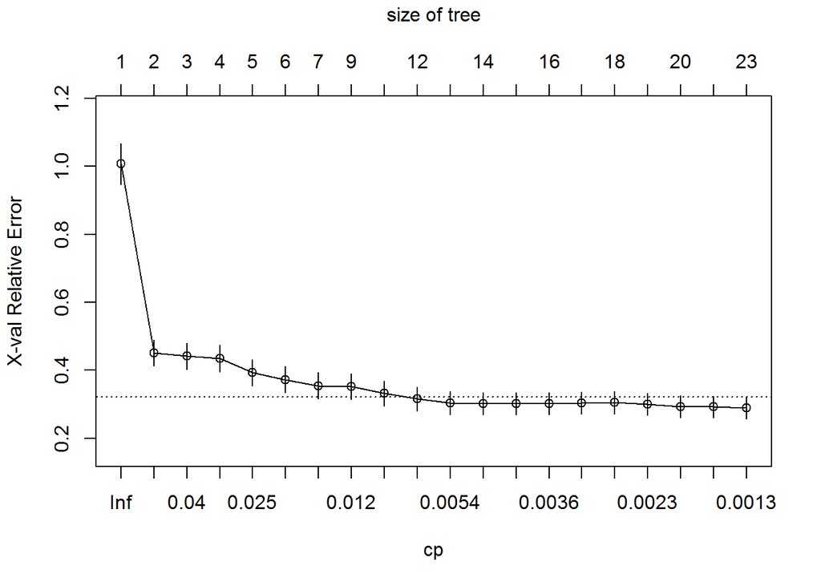

```r
plotcp(rpart_tree)
```

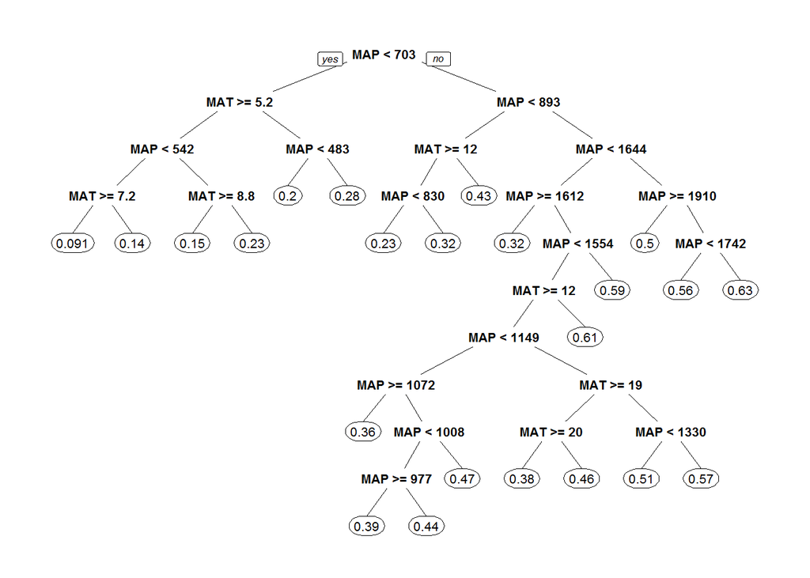

```r
rpart.plot(rpart_tree)
```

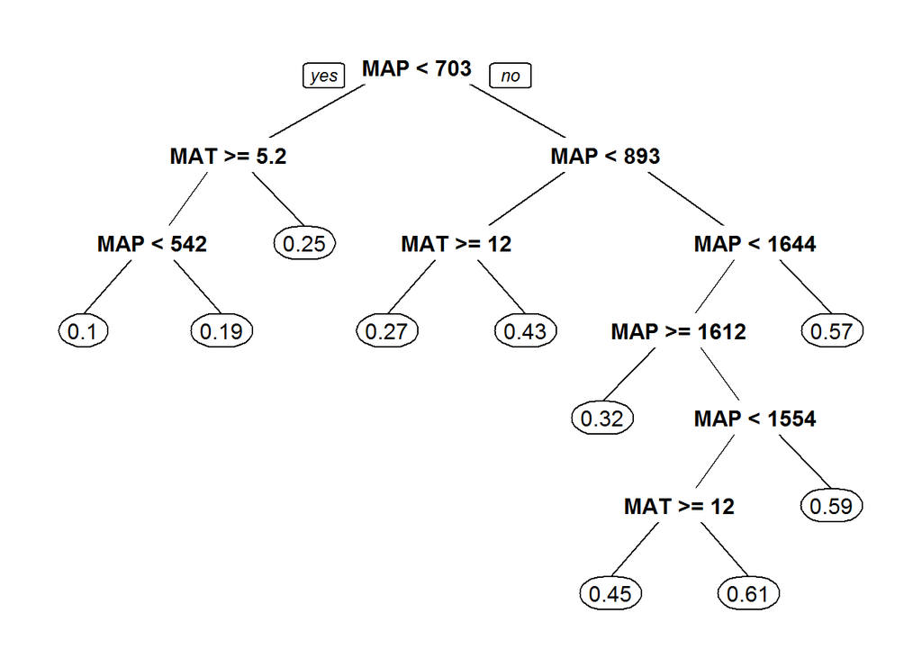

```r
#prune it and replot
rpart.plot(prune(rpart_tree,cp=0.01))
```

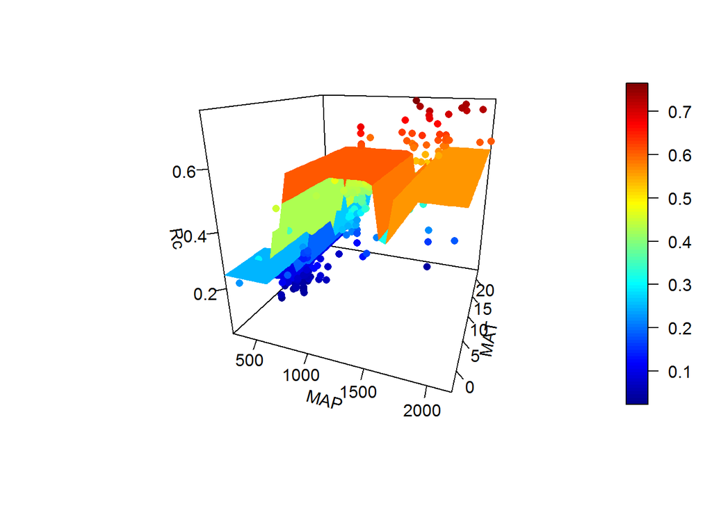

```r
#add in regression surface with interaction
grid.lines = 40
x.pred <- seq(min(MAP), max(MAP), length.out = grid.lines)
y.pred <- seq(min(MAT), max(MAT), length.out = grid.lines)
xy <- expand.grid( MAP = x.pred, MAT = y.pred)
z.pred <- matrix(ifelse(xy[,1]<542 & xy[,2]>=5.2,0.1,
                  ifelse(xy[,1]<703 & xy[,1]>=542 & xy[,2]>=5.2,0.19,
                  ifelse(xy[,1]<703 & xy[,2]<5.2,0.25,
                  ifelse(xy[,1]<893 & xy[,2]>=12,0.27,
                  ifelse(xy[,1]<893 & xy[,2]<12,0.43,
                  ifelse(xy[,1]>1644,0.57,
                  ifelse(xy[,1]>=1612,0.32,
                  ifelse(xy[,1]>1554,0.59,
                  ifelse(xy[,1]<1554 & xy[,2]>=12,0.45,
                  ifelse(xy[,1]<1554 & xy[,2]<12,0.61,NA)))))))))),
                 nrow = grid.lines, ncol = grid.lines)
# scatter plot with tree fit
scatter3D(x=MAP, y=MAT, z=Rc, pch = 16, cex = 1,
          theta = 20, phi = 20, ticktype = "detailed",
          xlab = "MAP", ylab = "MAT", zlab = "Rc",
          surf = list(x = x.pred, y = y.pred, z = z.pred))
```

[interactive chart not shown]

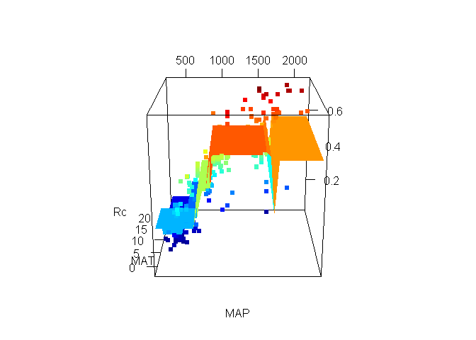

```r
plotrgl()
```

## A little more on the splits

Assuming we want to model a constant in each region, the mean is optimal. How are we doing the splits? For every point we are looking at the Residual Sum of Squares and trying to minimize that.

(From ESL) That is, we consider all predictors $X_1,...,X_p$, and all possible values of the cutpoint s for each of the predictors, and then choose the predictor and cutpoint such that the resulting tree has the lowest RSS. In greater detail, for any j and s, we define the pair of half-planes $R_1(j, s) = \{X|X_j < s\}\mbox{ and }R_2(j, s) = \{X|X_j \geq s\}$ and we seek the value of j and s that minimize the equation $\sum_{i:x_i\in R_1(j,s)}(y_i-\bar{y}_{R_1})^2+\sum_{i:x_i\in R_2(j,s)}(y_i-\bar{y}_{R_2})^2$